# JSC370 - HW4

Shih-Ting (Cindy) Huang

03/31/2022

# HPC

## Problem 1

Using microbenchmark to compare the runtime of the variation of the two functions, we find that `fun1` on average takes 566.595% more time than `fun1alt`. For function 2, `fun2` is on average 5.945% slower than `fun2alt`. Below is a full table of the runtime performance comparison with the unit microseconds.

Runtime comparison for functions 1 & 2 with their alternatives

| Function Name | Mean Runtime | Median Runtime | Times Evaluated |
| --- | --- | --- | --- |
| fun1(dat) | 135.912 | 130.55 | 100 |
| fun1alt(dat) | 20.389 | 7.90 | 100 |
| fun2(dat) | 251.547 | 239.30 | 100 |
| fun2alt(dat) | 237.431 | 211.85 | 100 |

## Problem 2

First, we try using `lapply` to simulate PI 4,000 times, each with 10,000 points. The resulting simulated value is:

```
## [1] 3.14124
```

Then, we try parallel computing with `parLapply`, yielding the following results:

```
## [1] 3.141548
```

By using parallel computing, we have reduced runtime by 35.6% from 2.5 to 1.61.

# ML

In the following steps, we will be examining the `hitters` dataset, which details information for 332 major league baseball players. We will compare the models’ performance for predicting players’ salaries based on provided features. NA observations are omitted because we won’t be able to calculate MSEs otherwise.

After separating the dataset into 70% training and 30% test set, we proceed with fitting different models.

## Step 1: Regression Tree

First, we fit a regression tree with the response variable `Salary` using the ANOVA method. The tree below shows the predicted value for each node as well as the percentage of the observations in the node.

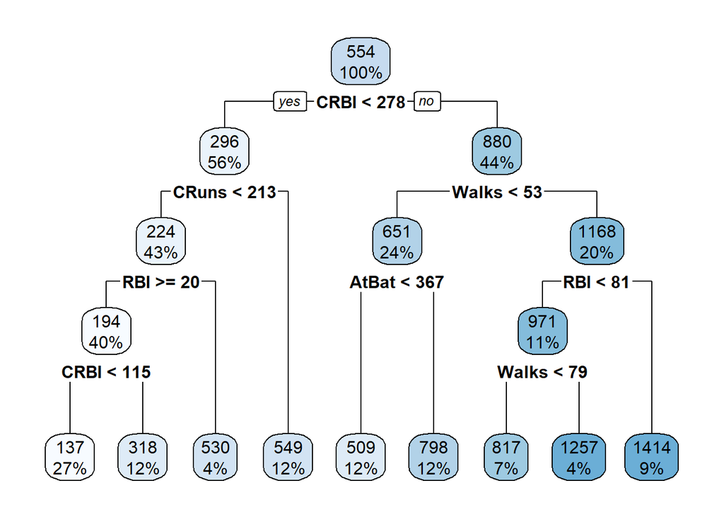

We then try to find the optimal cost complexity value for pruning the fitted tree by choosing the one with the lowest cross-validation error on the training set.

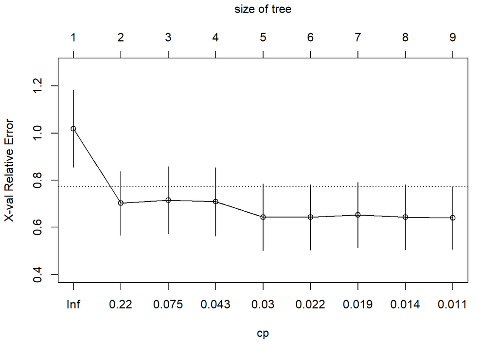

For this tree, the optimal CP value is 0.01.

Using the optimal CP, we pruned the tree to get the following new regression tree.

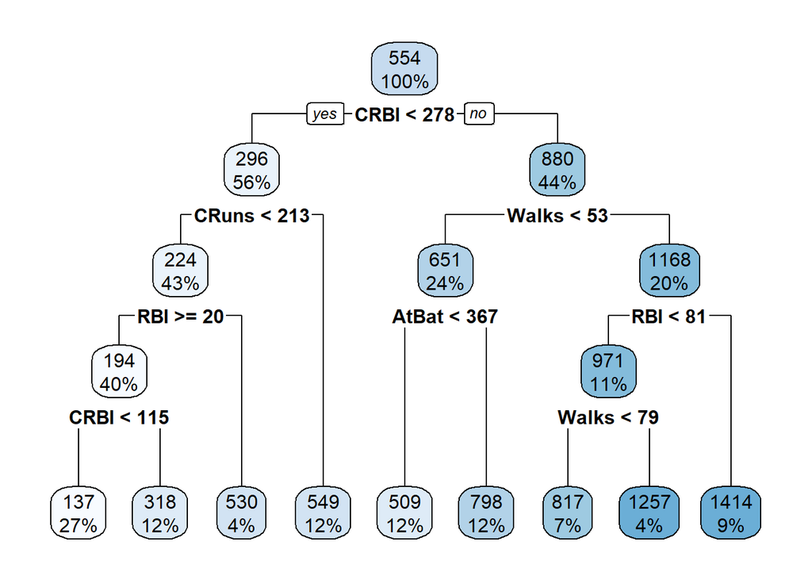

## Step 2: Bagging

Next, we attempt to predict `Salary` with bagging, from which we can get a plot showing the importance of each variable.

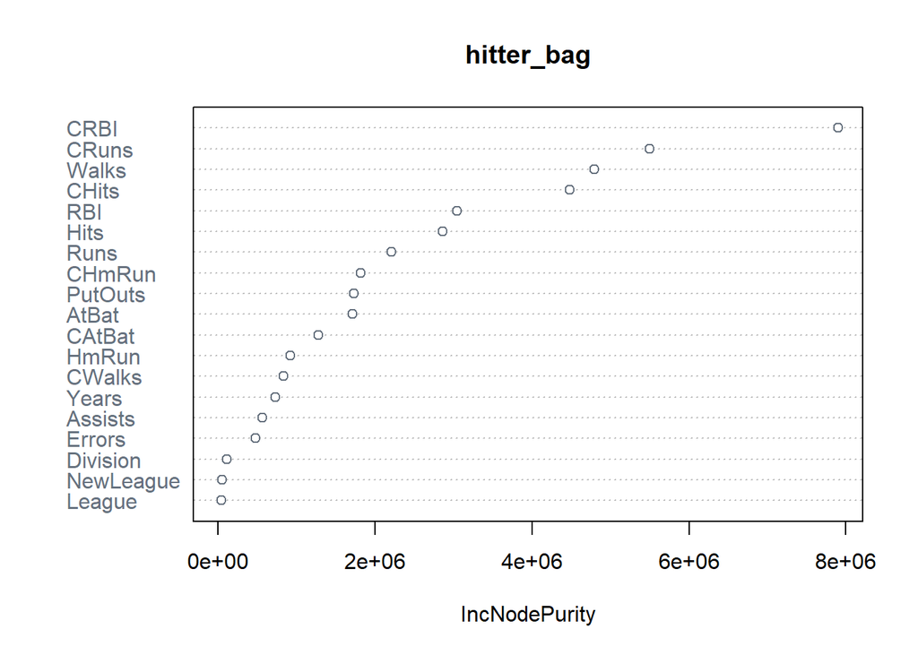

The x-axis `IncNodePurity` measures how much each variable has contributed to decreasing node impurity. The top 5 principal variables are:

- `CRBI`: Number of runs batted in during their career
- `CRuns`: Number of runs during their career
- `Walks`: Number of walks in 1986
- `CHits`: Number of hits during their career
- `RBI`: Number of runs batted in 1986

## Step 3: Random Forest

Fitting a random forest, our top 5 important variables are not too different from when we performed bagging.

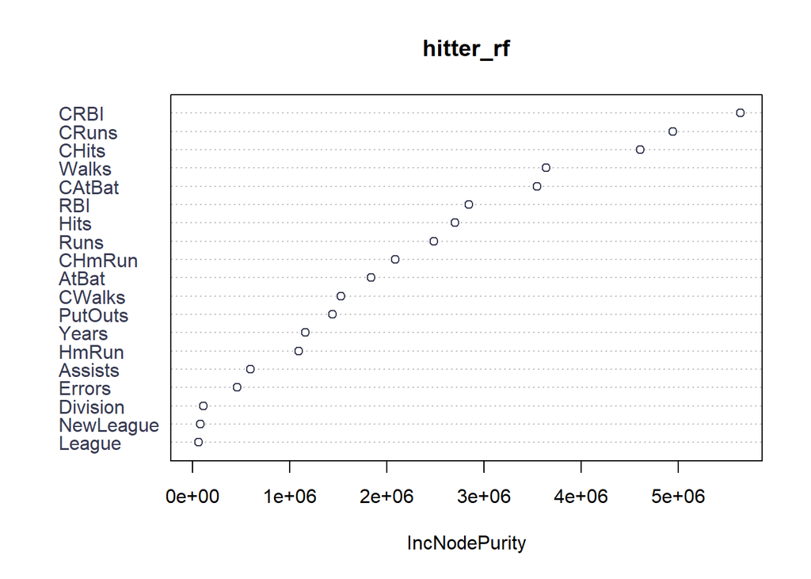

`CRBI` and `CRuns` are still the top 2. While `CHits` and `Walks` switched places, `RBI` is no longer among the top 5 and has been replaced by `CAtBat`, which is the number of times at bat during the player’s career.

## Step 4: Boosting

Next, we perform boosting with 1,000 trees on a range of shrinkage parameter ($\lambda$) values. Here, I have tried 9 values for $\lambda$: 0.0001, 0.001, 0.0025, 0.01, 0.1, 0.3, 0.5, 1, 1.5.

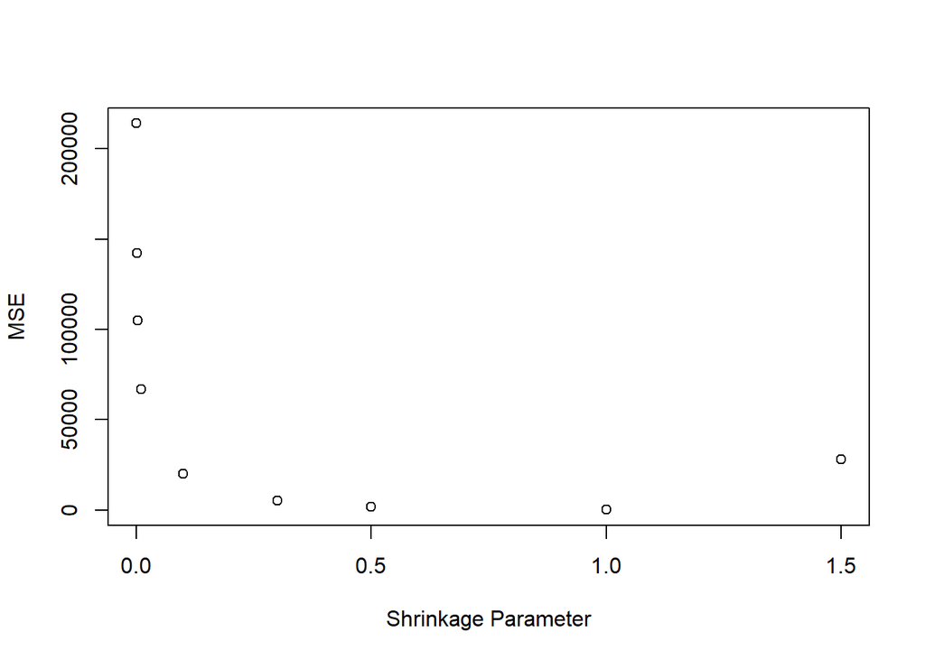

From the graph of $\lambda$ versus MSE, we see that the best value is 1. Using the model with the best shrinkage parameter on the training set, we construct its variable importance table and plot.

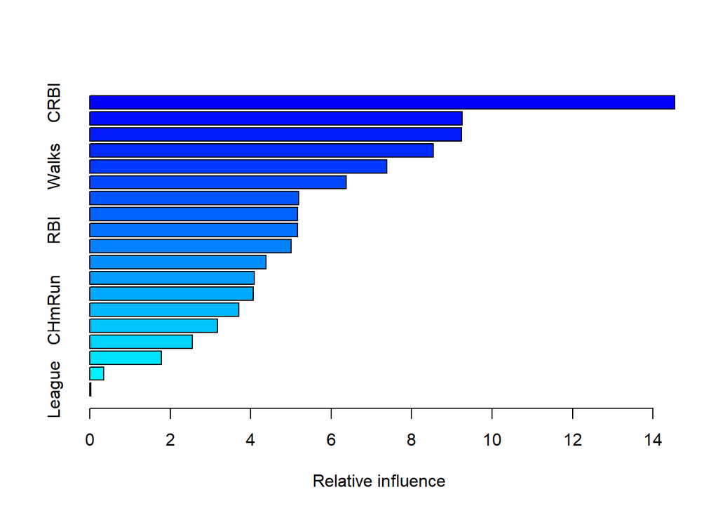

```
##                 var     rel.inf
## CRBI           CRBI 14.53926240
## AtBat         AtBat  9.25690523
## PutOuts     PutOuts  9.24079435
## HmRun         HmRun  8.53843456
## Walks         Walks  7.39058989
## Runs           Runs  6.37649833
## Hits           Hits  5.19954895
## Assists     Assists  5.16719293
## RBI             RBI  5.16386957
## CAtBat       CAtBat  5.00199423
## CRuns         CRuns  4.37738912
## CWalks       CWalks  4.09417467
## Errors       Errors  4.06638734
## CHmRun       CHmRun  3.70968838
## Years         Years  3.17690073
## CHits         CHits  2.54517303
## Division   Division  1.78367946
## NewLeague NewLeague  0.34545785
## League       League  0.02605899
```

The method used here is relative influence, which is likely the average reduction of a given metric (ex. MSE) across the base learners (trees) for each variable respectively. From the table, we notice that `CRBI` and `Walks` are again among the most significant predictors. However, GBM’s other choices differ, as `PutOuts`, `AtBat`, and `HmRun` have appeared in the top 5 for the first time. They represent the following:

- `PutOuts`: Number of put outs in 1986
- `AtBat`: Number of times at bat in 1986
- `HmRun`: Number of home runs in 1986

## Step 5: XGBoost

Our last model is XGBoost, which has historically yielded promising results. To attain the best results, we will perform a grid search on some of its parameters (`max_depth`, `nrounds`, and `eta`) to find the optimal set of parameters.

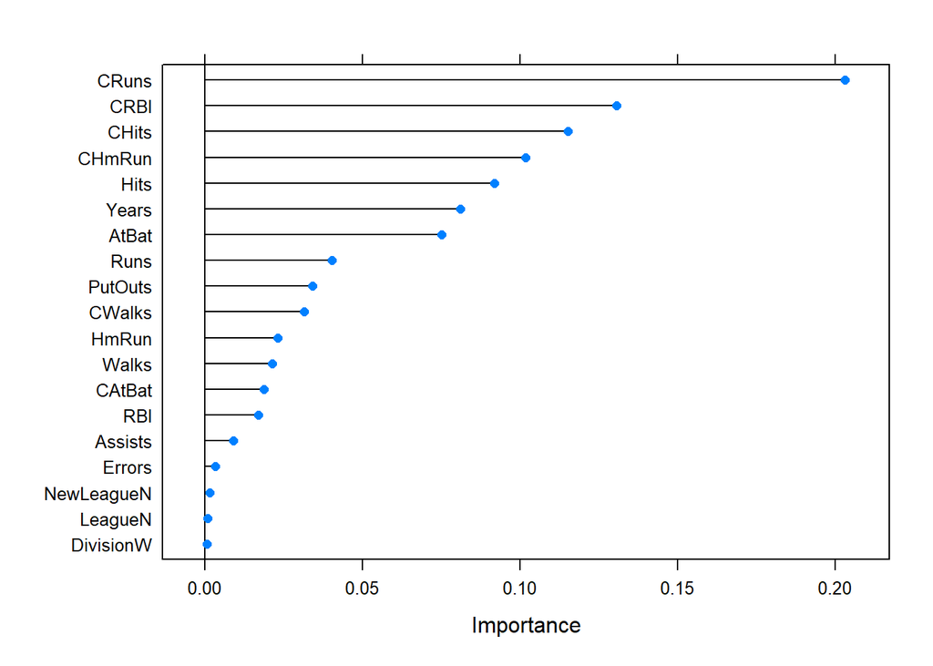

For XGBoost, we again see `CRuns`, `CRBI`, and `CHits` reappear. Although `HmRun` is not among the top 5 here, `CHmRun` is, indicating the importance of home runs in predicting the player’s salary. It is interesting to note that `Walks` and even `CWalks` are not considered very important in XGBoost.

The set of parameters that XGBoost has chosen for the final model after tuning are:

- `nrounds` = 50
- `max_depth` = 3
- `eta` = 0.3

## Step 6: Compare Performance

So which model is the best? To determine that, we shall calculate and compare the test MSE for each method.

Test set MSE of different models on the hitters dataset

| Model | MSE |
| --- | --- |
| Regression Tree | 55133.31 |
| Bagging | 38760.86 |
| Random Forest | 36084.52 |
| Boosting | 223802.00 |
| XGBoost | 45536.71 |

# Conclusion

From the above data, we discover that random forest yielded the lowest MSE on the test set, which could suggest that it is the best model with regards to this metric. In terms of predicting player salary, we also have some general insights from calculating variable importance for all the models:

- `CRBI`, the number of runs batted in during their career, is always in the top 2 significant features for all the models.
- `CRuns` and `CHits` are important (in the top 5) in all models except boosting.
- `Walks` is important in all models except XGBoost.

The several common variables in the top 5 can possibly give more certainty about their ability to predict the player’s salary. As such, we saw that often, the player’s salary is associated with some of their actions on the field, such as runs, walks, hits, and runs batted whether in a particular game or during their entire career. However, their number of errors or assists did not seem to matter as much. Lastly, we did not see the player’s league or division category playing a huge role, suggesting that perhaps those are not indicative of their corresponding salary.